# Risk Factor Analysis

## Outcome Variable

**Outcome Variable:** whz

## Predictor Variables

**Intervention Variable:** meducyrs

**Adjustment Set:**

- arm
- W_mage
- feducyrs
- hhwealth_quart
- W_mhtcm
- W_mwtkg
- W_mbmi
- W_gagebrth
- W_birthwt
- W_birthlen
- single
- W_nrooms
- impsan
- delta_W_mage
- delta_feducyrs
- delta_hhwealth_quart
- delta_W_mhtcm
- delta_W_mwtkg
- delta_W_mbmi
- delta_W_gagebrth
- delta_W_birthwt
- delta_W_birthlen
- delta_single
- delta_W_nrooms
- delta_impsan

## Stratifying Variables

The analysis was stratified on these variable(s):

- agecat
- studyid
- country

## Data Summary

| agecat | studyid | country | meducyrs | n_cell | n |
| --- | --- | --- | --- | --- | --- |
| Birth | ki0047075b-MAL-ED | BANGLADESH | High | 64 | 175 |
| Birth | ki0047075b-MAL-ED | BANGLADESH | Low | 60 | 175 |
| Birth | ki0047075b-MAL-ED | BANGLADESH | Medium | 51 | 175 |
| Birth | ki0047075b-MAL-ED | BRAZIL | High | 18 | 62 |
| Birth | ki0047075b-MAL-ED | BRAZIL | Low | 17 | 62 |
| Birth | ki0047075b-MAL-ED | BRAZIL | Medium | 27 | 62 |
| Birth | ki0047075b-MAL-ED | INDIA | High | 8 | 38 |
| Birth | ki0047075b-MAL-ED | INDIA | Low | 18 | 38 |
| Birth | ki0047075b-MAL-ED | INDIA | Medium | 12 | 38 |
| Birth | ki0047075b-MAL-ED | NEPAL | High | 5 | 24 |
| Birth | ki0047075b-MAL-ED | NEPAL | Low | 12 | 24 |
| Birth | ki0047075b-MAL-ED | NEPAL | Medium | 7 | 24 |
| Birth | ki0047075b-MAL-ED | PERU | High | 65 | 228 |
| Birth | ki0047075b-MAL-ED | PERU | Low | 83 | 228 |
| Birth | ki0047075b-MAL-ED | PERU | Medium | 80 | 228 |
| Birth | ki0047075b-MAL-ED | SOUTH AFRICA | High | 35 | 120 |
| Birth | ki0047075b-MAL-ED | SOUTH AFRICA | Low | 59 | 120 |
| Birth | ki0047075b-MAL-ED | SOUTH AFRICA | Medium | 26 | 120 |
| Birth | ki0047075b-MAL-ED | TANZANIA, UNITED REPUBLIC OF | High | 7 | 97 |
| Birth | ki0047075b-MAL-ED | TANZANIA, UNITED REPUBLIC OF | Low | 32 | 97 |
| Birth | ki0047075b-MAL-ED | TANZANIA, UNITED REPUBLIC OF | Medium | 58 | 97 |
| Birth | ki1000108-CMC-V-BCS-2002 | INDIA | High | 49 | 86 |
| Birth | ki1000108-CMC-V-BCS-2002 | INDIA | Low | 15 | 86 |
| Birth | ki1000108-CMC-V-BCS-2002 | INDIA | Medium | 22 | 86 |
| Birth | ki1000108-IRC | INDIA | High | 101 | 343 |
| Birth | ki1000108-IRC | INDIA | Low | 126 | 343 |
| Birth | ki1000108-IRC | INDIA | Medium | 116 | 343 |
| Birth | ki1000109-EE | PAKISTAN | High | 5 | 177 |
| Birth | ki1000109-EE | PAKISTAN | Low | 156 | 177 |
| Birth | ki1000109-EE | PAKISTAN | Medium | 16 | 177 |

[output cut: 183 more lines]

The following strata were considered:

- agecat: 24 months, studyid: ki0047075b-MAL-ED, country: BANGLADESH
- agecat: 24 months, studyid: ki0047075b-MAL-ED, country: BRAZIL
- agecat: 24 months, studyid: ki0047075b-MAL-ED, country: INDIA
- agecat: 24 months, studyid: ki0047075b-MAL-ED, country: NEPAL
- agecat: 24 months, studyid: ki0047075b-MAL-ED, country: PERU
- agecat: 24 months, studyid: ki0047075b-MAL-ED, country: SOUTH AFRICA
- agecat: 24 months, studyid: ki0047075b-MAL-ED, country: TANZANIA, UNITED REPUBLIC OF
- agecat: 24 months, studyid: ki1000108-CMC-V-BCS-2002, country: INDIA
- agecat: 24 months, studyid: ki1000108-IRC, country: INDIA
- agecat: 24 months, studyid: ki1000109-EE, country: PAKISTAN
- agecat: 24 months, studyid: ki1017093-NIH-Birth, country: BANGLADESH
- agecat: 24 months, studyid: ki1017093b-PROVIDE, country: BANGLADESH
- agecat: 24 months, studyid: ki1017093c-NIH-Crypto, country: BANGLADESH
- agecat: 24 months, studyid: ki1066203-TanzaniaChild2, country: TANZANIA, UNITED REPUBLIC OF
- agecat: 24 months, studyid: ki1113344-GMS-Nepal, country: NEPAL
- agecat: 24 months, studyid: ki1119695-PROBIT, country: BELARUS
- agecat: 24 months, studyid: ki1126311-ZVITAMBO, country: ZIMBABWE
- agecat: 24 months, studyid: ki1135781-COHORTS, country: GUATEMALA
- agecat: 24 months, studyid: ki1135781-COHORTS, country: INDIA
- agecat: 24 months, studyid: ki1135781-COHORTS, country: PHILIPPINES
- agecat: 24 months, studyid: ki1148112-LCNI-5, country: MALAWI
- agecat: 24 months, studyid: kiGH5241-JiVitA-3, country: BANGLADESH
- agecat: 24 months, studyid: kiGH5241-JiVitA-4, country: BANGLADESH
- agecat: 6 months, studyid: ki0047075b-MAL-ED, country: BANGLADESH
- agecat: 6 months, studyid: ki0047075b-MAL-ED, country: BRAZIL
- agecat: 6 months, studyid: ki0047075b-MAL-ED, country: INDIA
- agecat: 6 months, studyid: ki0047075b-MAL-ED, country: NEPAL
- agecat: 6 months, studyid: ki0047075b-MAL-ED, country: PERU
- agecat: 6 months, studyid: ki0047075b-MAL-ED, country: SOUTH AFRICA
- agecat: 6 months, studyid: ki0047075b-MAL-ED, country: TANZANIA, UNITED REPUBLIC OF
- agecat: 6 months, studyid: ki1000108-CMC-V-BCS-2002, country: INDIA
- agecat: 6 months, studyid: ki1000108-IRC, country: INDIA
- agecat: 6 months, studyid: ki1000109-EE, country: PAKISTAN
- agecat: 6 months, studyid: ki1000304b-SAS-CompFeed, country: INDIA
- agecat: 6 months, studyid: ki1000304b-SAS-FoodSuppl, country: INDIA
- agecat: 6 months, studyid: ki1017093-NIH-Birth, country: BANGLADESH
- agecat: 6 months, studyid: ki1017093b-PROVIDE, country: BANGLADESH
- agecat: 6 months, studyid: ki1017093c-NIH-Crypto, country: BANGLADESH
- agecat: 6 months, studyid: ki1066203-TanzaniaChild2, country: TANZANIA, UNITED REPUBLIC OF
- agecat: 6 months, studyid: ki1112895-Guatemala BSC, country: GUATEMALA
- agecat: 6 months, studyid: ki1113344-GMS-Nepal, country: NEPAL
- agecat: 6 months, studyid: ki1119695-PROBIT, country: BELARUS
- agecat: 6 months, studyid: ki1126311-ZVITAMBO, country: ZIMBABWE
- agecat: 6 months, studyid: ki1135781-COHORTS, country: GUATEMALA
- agecat: 6 months, studyid: ki1135781-COHORTS, country: INDIA
- agecat: 6 months, studyid: ki1135781-COHORTS, country: PHILIPPINES
- agecat: 6 months, studyid: ki1148112-LCNI-5, country: MALAWI
- agecat: 6 months, studyid: kiGH5241-JiVitA-3, country: BANGLADESH
- agecat: 6 months, studyid: kiGH5241-JiVitA-4, country: BANGLADESH
- agecat: Birth, studyid: ki0047075b-MAL-ED, country: BANGLADESH
- agecat: Birth, studyid: ki0047075b-MAL-ED, country: BRAZIL
- agecat: Birth, studyid: ki0047075b-MAL-ED, country: INDIA
- agecat: Birth, studyid: ki0047075b-MAL-ED, country: NEPAL
- agecat: Birth, studyid: ki0047075b-MAL-ED, country: PERU
- agecat: Birth, studyid: ki0047075b-MAL-ED, country: SOUTH AFRICA
- agecat: Birth, studyid: ki0047075b-MAL-ED, country: TANZANIA, UNITED REPUBLIC OF
- agecat: Birth, studyid: ki1000108-CMC-V-BCS-2002, country: INDIA
- agecat: Birth, studyid: ki1000108-IRC, country: INDIA
- agecat: Birth, studyid: ki1000109-EE, country: PAKISTAN
- agecat: Birth, studyid: ki1000304b-SAS-CompFeed, country: INDIA
- agecat: Birth, studyid: ki1017093-NIH-Birth, country: BANGLADESH
- agecat: Birth, studyid: ki1017093b-PROVIDE, country: BANGLADESH
- agecat: Birth, studyid: ki1017093c-NIH-Crypto, country: BANGLADESH
- agecat: Birth, studyid: ki1113344-GMS-Nepal, country: NEPAL
- agecat: Birth, studyid: ki1119695-PROBIT, country: BELARUS
- agecat: Birth, studyid: ki1126311-ZVITAMBO, country: ZIMBABWE
- agecat: Birth, studyid: ki1135781-COHORTS, country: GUATEMALA
- agecat: Birth, studyid: ki1135781-COHORTS, country: INDIA
- agecat: Birth, studyid: ki1135781-COHORTS, country: PHILIPPINES
- agecat: Birth, studyid: kiGH5241-JiVitA-3, country: BANGLADESH
- agecat: Birth, studyid: kiGH5241-JiVitA-4, country: BANGLADESH

### Dropped Strata

Some strata were dropped due to rare outcomes:

- agecat: 24 months, studyid: ki1066203-TanzaniaChild2, country: TANZANIA, UNITED REPUBLIC OF

## Methods Detail

We’re interested in the causal parameters $E[Y_a]$ for all values of $a \in \mathcal{A}$. These parameters represent the mean outcome if, possibly contrary to fact, we intervened to set all units to have $A=a$. Under the randomization and positivity assumptions, these are identified by the statistical parameters $\psi_a=E_W[E_{Y|A,W}(Y|A=a,W)]$. In addition, we’re interested in the mean of $Y$, $E[Y]$ under no intervention (the observed mean). We will estimate these parameters by using SuperLearner to fit the relevant likelihood factors – $E_{Y|A,W}(Y|A=a,W)$ and $p(A=a|W)$, and then updating our likelihood fit using a joint TMLE.

For unadjusted analyses ($W=\{\}$), initial likelihoods were estimated using Lrnr_glm to estimate the simple $E(Y|A)$ and Lrnr_mean to estimate $p(A)$. For adjusted analyses, a small library containing Lrnr_glmnet, Lrnr_xgboost, and Lrnr_mean was used.

Having estimated these parameters, we will then use the delta method to estimate relative risks and attributable risks relative to a prespecified baseline level of $A$.

# Results Detail

## Results Plots

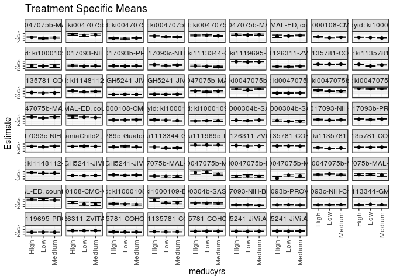

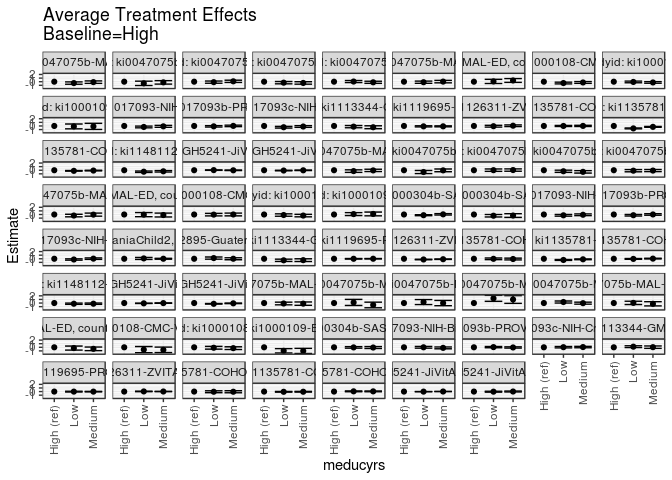

[figure not shown]

## Results Table

### Parameter: TSM

| agecat | studyid | country | intervention_level | baseline_level | estimate | ci_lower | ci_upper |
| --- | --- | --- | --- | --- | --- | --- | --- |
| Birth | ki0047075b-MAL-ED | BANGLADESH | High | NA | -0.8180804 | -1.0381899 | -0.5979708 |
| Birth | ki0047075b-MAL-ED | BANGLADESH | Low | NA | -0.9437735 | -1.2369216 | -0.6506254 |
| Birth | ki0047075b-MAL-ED | BANGLADESH | Medium | NA | -0.9853661 | -1.3937223 | -0.5770098 |
| Birth | ki0047075b-MAL-ED | BRAZIL | High | NA | 0.5719133 | -0.0691895 | 1.2130161 |
| Birth | ki0047075b-MAL-ED | BRAZIL | Low | NA | 0.7385933 | 0.1855745 | 1.2916122 |
| Birth | ki0047075b-MAL-ED | BRAZIL | Medium | NA | 0.0390804 | -0.4070222 | 0.4851830 |
| Birth | ki0047075b-MAL-ED | INDIA | High | NA | -1.0262500 | -1.5172747 | -0.5352253 |
| Birth | ki0047075b-MAL-ED | INDIA | Low | NA | -0.7572222 | -1.2526878 | -0.2617566 |
| Birth | ki0047075b-MAL-ED | INDIA | Medium | NA | -1.0366667 | -1.5769678 | -0.4963655 |
| Birth | ki0047075b-MAL-ED | NEPAL | High | NA | -1.7180000 | -2.4635498 | -0.9724502 |
| Birth | ki0047075b-MAL-ED | NEPAL | Low | NA | -0.4158333 | -0.7761719 | -0.0554948 |
| Birth | ki0047075b-MAL-ED | NEPAL | Medium | NA | -0.7314286 | -1.5015148 | 0.0386577 |
| Birth | ki0047075b-MAL-ED | PERU | High | NA | -0.1507020 | -0.3342805 | 0.0328765 |
| Birth | ki0047075b-MAL-ED | PERU | Low | NA | 0.1306698 | -0.0856885 | 0.3470281 |
| Birth | ki0047075b-MAL-ED | PERU | Medium | NA | -0.1882345 | -0.3992233 | 0.0227542 |
| Birth | ki0047075b-MAL-ED | SOUTH AFRICA | High | NA | -0.1700634 | -0.4974027 | 0.1572760 |
| Birth | ki0047075b-MAL-ED | SOUTH AFRICA | Low | NA | -0.1278180 | -0.4519323 | 0.1962963 |
| Birth | ki0047075b-MAL-ED | SOUTH AFRICA | Medium | NA | -0.3819325 | -0.8642238 | 0.1003588 |
| Birth | ki0047075b-MAL-ED | TANZANIA, UNITED REPUBLIC OF | High | NA | 1.1228571 | 0.7098698 | 1.5358445 |
| Birth | ki0047075b-MAL-ED | TANZANIA, UNITED REPUBLIC OF | Low | NA | 0.9103125 | 0.5359266 | 1.2846984 |
| Birth | ki0047075b-MAL-ED | TANZANIA, UNITED REPUBLIC OF | Medium | NA | 0.6998276 | 0.4307367 | 0.9689185 |
| Birth | ki1000108-CMC-V-BCS-2002 | INDIA | High | NA | -0.2897104 | -0.6854409 | 0.1060201 |
| Birth | ki1000108-CMC-V-BCS-2002 | INDIA | Low | NA | -0.9281462 | -1.6902276 | -0.1660648 |
| Birth | ki1000108-CMC-V-BCS-2002 | INDIA | Medium | NA | -0.9966798 | -1.6228514 | -0.3705081 |
| Birth | ki1000108-IRC | INDIA | High | NA | -0.8850959 | -1.1815047 | -0.5886870 |
| Birth | ki1000108-IRC | INDIA | Low | NA | -1.0125305 | -1.2973579 | -0.7277030 |
| Birth | ki1000108-IRC | INDIA | Medium | NA | -1.1177867 | -1.3906053 | -0.8449680 |
| Birth | ki1000109-EE | PAKISTAN | High | NA | 0.6080000 | 0.0422458 | 1.1737542 |
| Birth | ki1000109-EE | PAKISTAN | Low | NA | -0.3569551 | -0.5627099 | -0.1512003 |
| Birth | ki1000109-EE | PAKISTAN | Medium | NA | -0.3968750 | -0.8274988 | 0.0337488 |

[output cut: 180 more lines]

### Parameter: E(Y)

| agecat | studyid | country | intervention_level | baseline_level | estimate | ci_lower | ci_upper |
| --- | --- | --- | --- | --- | --- | --- | --- |
| Birth | ki0047075b-MAL-ED | BANGLADESH | NA | NA | -0.9101143 | -1.0708516 | -0.7493770 |
| Birth | ki0047075b-MAL-ED | BRAZIL | NA | NA | 0.4029032 | 0.0896793 | 0.7161272 |
| Birth | ki0047075b-MAL-ED | INDIA | NA | NA | -0.9021053 | -1.2132997 | -0.5909108 |
| Birth | ki0047075b-MAL-ED | NEPAL | NA | NA | -0.7791667 | -1.1649642 | -0.3933692 |
| Birth | ki0047075b-MAL-ED | PERU | NA | NA | -0.0520175 | -0.1725298 | 0.0684947 |
| Birth | ki0047075b-MAL-ED | SOUTH AFRICA | NA | NA | -0.1925833 | -0.4053570 | 0.0201904 |
| Birth | ki0047075b-MAL-ED | TANZANIA, UNITED REPUBLIC OF | NA | NA | 0.7997938 | 0.5930740 | 1.0065137 |
| Birth | ki1000108-CMC-V-BCS-2002 | INDIA | NA | NA | -0.4648256 | -0.7643210 | -0.1653302 |
| Birth | ki1000108-IRC | INDIA | NA | NA | -1.0105831 | -1.1973019 | -0.8238643 |
| Birth | ki1000109-EE | PAKISTAN | NA | NA | -0.3333051 | -0.5209779 | -0.1456323 |
| Birth | ki1000304b-SAS-CompFeed | INDIA | NA | NA | -0.6700453 | -0.8474950 | -0.4925957 |
| Birth | ki1017093-NIH-Birth | BANGLADESH | NA | NA | -1.3499217 | -1.4444634 | -1.2553801 |
| Birth | ki1017093b-PROVIDE | BANGLADESH | NA | NA | -1.2984586 | -1.3752758 | -1.2216415 |
| Birth | ki1017093c-NIH-Crypto | BANGLADESH | NA | NA | -1.2441513 | -1.3281130 | -1.1601897 |
| Birth | ki1113344-GMS-Nepal | NEPAL | NA | NA | -1.1182629 | -1.2060675 | -1.0304584 |
| Birth | ki1119695-PROBIT | BELARUS | NA | NA | -1.1448633 | -1.3544229 | -0.9353037 |
| Birth | ki1126311-ZVITAMBO | ZIMBABWE | NA | NA | -0.5152927 | -0.5411678 | -0.4894176 |
| Birth | ki1135781-COHORTS | GUATEMALA | NA | NA | -1.0590508 | -1.1604735 | -0.9576281 |
| Birth | ki1135781-COHORTS | INDIA | NA | NA | -0.9831277 | -1.0164986 | -0.9497568 |
| Birth | ki1135781-COHORTS | PHILIPPINES | NA | NA | -0.7427251 | -0.7890855 | -0.6963647 |
| Birth | kiGH5241-JiVitA-3 | BANGLADESH | NA | NA | -0.7503115 | -0.7681644 | -0.7324587 |
| Birth | kiGH5241-JiVitA-4 | BANGLADESH | NA | NA | -0.6895483 | -0.7419864 | -0.6371102 |
| 6 months | ki0047075b-MAL-ED | BANGLADESH | NA | NA | -0.0732738 | -0.2158247 | 0.0692771 |
| 6 months | ki0047075b-MAL-ED | BRAZIL | NA | NA | 0.9741026 | 0.8090337 | 1.1391714 |
| 6 months | ki0047075b-MAL-ED | INDIA | NA | NA | -0.6858814 | -0.8229164 | -0.5488465 |
| 6 months | ki0047075b-MAL-ED | NEPAL | NA | NA | 0.1237029 | -0.0091418 | 0.2565476 |
| 6 months | ki0047075b-MAL-ED | PERU | NA | NA | 1.0606863 | 0.9388664 | 1.1825061 |
| 6 months | ki0047075b-MAL-ED | SOUTH AFRICA | NA | NA | 0.5427231 | 0.3906363 | 0.6948099 |
| 6 months | ki0047075b-MAL-ED | TANZANIA, UNITED REPUBLIC OF | NA | NA | 0.5536864 | 0.4102695 | 0.6971033 |
| 6 months | ki1000108-CMC-V-BCS-2002 | INDIA | NA | NA | -0.5026766 | -0.6536848 | -0.3516685 |
| 6 months | ki1000108-IRC | INDIA | NA | NA | -0.5989297 | -0.7344491 | -0.4634104 |
| 6 months | ki1000109-EE | PAKISTAN | NA | NA | -0.7785977 | -0.8934940 | -0.6637013 |
| 6 months | ki1000304b-SAS-CompFeed | INDIA | NA | NA | -0.6657084 | -0.8024377 | -0.5289791 |
| 6 months | ki1000304b-SAS-FoodSuppl | INDIA | NA | NA | -1.0121579 | -1.1280429 | -0.8962729 |
| 6 months | ki1017093-NIH-Birth | BANGLADESH | NA | NA | -0.4474038 | -0.5378167 | -0.3569909 |
| 6 months | ki1017093b-PROVIDE | BANGLADESH | NA | NA | -0.1990907 | -0.2817968 | -0.1163845 |
| 6 months | ki1017093c-NIH-Crypto | BANGLADESH | NA | NA | 0.0297622 | -0.0491685 | 0.1086930 |
| 6 months | ki1066203-TanzaniaChild2 | TANZANIA, UNITED REPUBLIC OF | NA | NA | 0.0807224 | 0.0278917 | 0.1335530 |
| 6 months | ki1112895-Guatemala BSC | GUATEMALA | NA | NA | -0.0568833 | -0.1722874 | 0.0585208 |
| 6 months | ki1113344-GMS-Nepal | NEPAL | NA | NA | -0.6087819 | -0.6949591 | -0.5226048 |
| 6 months | ki1119695-PROBIT | BELARUS | NA | NA | 0.5792439 | 0.5193388 | 0.6391490 |
| 6 months | ki1126311-ZVITAMBO | ZIMBABWE | NA | NA | 0.3101107 | 0.2844075 | 0.3358139 |
| 6 months | ki1135781-COHORTS | GUATEMALA | NA | NA | 0.1972718 | 0.1253735 | 0.2691700 |
| 6 months | ki1135781-COHORTS | INDIA | NA | NA | -0.7006307 | -0.7314213 | -0.6698400 |
| 6 months | ki1135781-COHORTS | PHILIPPINES | NA | NA | -0.2938433 | -0.3352064 | -0.2524802 |
| 6 months | ki1148112-LCNI-5 | MALAWI | NA | NA | 0.4399754 | 0.3683855 | 0.5115653 |
| 6 months | kiGH5241-JiVitA-3 | BANGLADESH | NA | NA | -0.5927772 | -0.6123363 | -0.5732182 |
| 6 months | kiGH5241-JiVitA-4 | BANGLADESH | NA | NA | -0.3903558 | -0.4277318 | -0.3529799 |
| 24 months | ki0047075b-MAL-ED | BANGLADESH | NA | NA | -0.7634795 | -0.9002125 | -0.6267466 |
| 24 months | ki0047075b-MAL-ED | BRAZIL | NA | NA | 0.4586012 | 0.2509873 | 0.6662151 |
| 24 months | ki0047075b-MAL-ED | INDIA | NA | NA | -0.9446231 | -1.0689273 | -0.8203189 |
| 24 months | ki0047075b-MAL-ED | NEPAL | NA | NA | -0.3599765 | -0.4780748 | -0.2418783 |
| 24 months | ki0047075b-MAL-ED | PERU | NA | NA | 0.1205000 | -0.0000440 | 0.2410440 |
| 24 months | ki0047075b-MAL-ED | SOUTH AFRICA | NA | NA | 0.4148529 | 0.2940577 | 0.5356481 |
| 24 months | ki0047075b-MAL-ED | TANZANIA, UNITED REPUBLIC OF | NA | NA | 0.0906000 | -0.0489294 | 0.2301294 |
| 24 months | ki1000108-CMC-V-BCS-2002 | INDIA | NA | NA | -0.5571505 | -0.6585247 | -0.4557763 |
| 24 months | ki1000108-IRC | INDIA | NA | NA | -0.7458150 | -0.8368180 | -0.6548120 |
| 24 months | ki1000109-EE | PAKISTAN | NA | NA | -1.0042771 | -1.1523338 | -0.8562205 |
| 24 months | ki1017093-NIH-Birth | BANGLADESH | NA | NA | -0.9115790 | -1.0095022 | -0.8136559 |
| 24 months | ki1017093b-PROVIDE | BANGLADESH | NA | NA | -0.8928670 | -0.9755153 | -0.8102187 |
| 24 months | ki1017093c-NIH-Crypto | BANGLADESH | NA | NA | -0.6103502 | -0.7050157 | -0.5156847 |
| 24 months | ki1113344-GMS-Nepal | NEPAL | NA | NA | -1.1372176 | -1.2263063 | -1.0481290 |
| 24 months | ki1119695-PROBIT | BELARUS | NA | NA | 0.6874295 | 0.5756922 | 0.7991668 |
| 24 months | ki1126311-ZVITAMBO | ZIMBABWE | NA | NA | -1.1825404 | -1.2814625 | -1.0836183 |
| 24 months | ki1135781-COHORTS | GUATEMALA | NA | NA | -0.2765075 | -0.3306839 | -0.2223311 |
| 24 months | ki1135781-COHORTS | INDIA | NA | NA | -0.6386606 | -0.6699072 | -0.6074140 |
| 24 months | ki1135781-COHORTS | PHILIPPINES | NA | NA | -0.6099592 | -0.6467541 | -0.5731643 |
| 24 months | ki1148112-LCNI-5 | MALAWI | NA | NA | -0.0441457 | -0.1265899 | 0.0382985 |
| 24 months | kiGH5241-JiVitA-3 | BANGLADESH | NA | NA | -1.2990923 | -1.3224665 | -1.2757181 |
| 24 months | kiGH5241-JiVitA-4 | BANGLADESH | NA | NA | -1.2243057 | -1.2562915 | -1.1923198 |

### Parameter: ATE

| agecat | studyid | country | intervention_level | baseline_level | estimate | ci_lower | ci_upper |
| --- | --- | --- | --- | --- | --- | --- | --- |
| Birth | ki0047075b-MAL-ED | BANGLADESH | High | High | 0.0000000 | 0.0000000 | 0.0000000 |
| Birth | ki0047075b-MAL-ED | BANGLADESH | Low | High | -0.1256931 | -0.4923661 | 0.2409799 |
| Birth | ki0047075b-MAL-ED | BANGLADESH | Medium | High | -0.1672857 | -0.6311335 | 0.2965622 |
| Birth | ki0047075b-MAL-ED | BRAZIL | High | High | 0.0000000 | 0.0000000 | 0.0000000 |
| Birth | ki0047075b-MAL-ED | BRAZIL | Low | High | 0.1666801 | -0.6735654 | 1.0069256 |
| Birth | ki0047075b-MAL-ED | BRAZIL | Medium | High | -0.5328329 | -1.3073756 | 0.2417098 |
| Birth | ki0047075b-MAL-ED | INDIA | High | High | 0.0000000 | 0.0000000 | 0.0000000 |
| Birth | ki0047075b-MAL-ED | INDIA | Low | High | 0.2690278 | -0.4285333 | 0.9665889 |
| Birth | ki0047075b-MAL-ED | INDIA | Medium | High | -0.0104167 | -0.7405061 | 0.7196728 |
| Birth | ki0047075b-MAL-ED | NEPAL | High | High | 0.0000000 | 0.0000000 | 0.0000000 |
| Birth | ki0047075b-MAL-ED | NEPAL | Low | High | 1.3021667 | 0.4741036 | 2.1302297 |
| Birth | ki0047075b-MAL-ED | NEPAL | Medium | High | 0.9865714 | -0.0852855 | 2.0584284 |
| Birth | ki0047075b-MAL-ED | PERU | High | High | 0.0000000 | 0.0000000 | 0.0000000 |
| Birth | ki0047075b-MAL-ED | PERU | Low | High | 0.2813718 | -0.0021183 | 0.5648619 |
| Birth | ki0047075b-MAL-ED | PERU | Medium | High | -0.0375325 | -0.3183585 | 0.2432934 |
| Birth | ki0047075b-MAL-ED | SOUTH AFRICA | High | High | 0.0000000 | 0.0000000 | 0.0000000 |
| Birth | ki0047075b-MAL-ED | SOUTH AFRICA | Low | High | 0.0422454 | -0.4151803 | 0.4996710 |
| Birth | ki0047075b-MAL-ED | SOUTH AFRICA | Medium | High | -0.2118691 | -0.7914635 | 0.3677253 |
| Birth | ki0047075b-MAL-ED | TANZANIA, UNITED REPUBLIC OF | High | High | 0.0000000 | 0.0000000 | 0.0000000 |
| Birth | ki0047075b-MAL-ED | TANZANIA, UNITED REPUBLIC OF | Low | High | -0.2125446 | -0.7699703 | 0.3448810 |
| Birth | ki0047075b-MAL-ED | TANZANIA, UNITED REPUBLIC OF | Medium | High | -0.4230296 | -0.9159478 | 0.0698887 |
| Birth | ki1000108-CMC-V-BCS-2002 | INDIA | High | High | 0.0000000 | 0.0000000 | 0.0000000 |
| Birth | ki1000108-CMC-V-BCS-2002 | INDIA | Low | High | -0.6384357 | -1.4890622 | 0.2121907 |
| Birth | ki1000108-CMC-V-BCS-2002 | INDIA | Medium | High | -0.7069693 | -1.4667451 | 0.0528064 |
| Birth | ki1000108-IRC | INDIA | High | High | 0.0000000 | 0.0000000 | 0.0000000 |
| Birth | ki1000108-IRC | INDIA | Low | High | -0.1274346 | -0.5059124 | 0.2510432 |
| Birth | ki1000108-IRC | INDIA | Medium | High | -0.2326908 | -0.6036586 | 0.1382769 |
| Birth | ki1000109-EE | PAKISTAN | High | High | 0.0000000 | 0.0000000 | 0.0000000 |
| Birth | ki1000109-EE | PAKISTAN | Low | High | -0.9649551 | -1.5669625 | -0.3629478 |
| Birth | ki1000109-EE | PAKISTAN | Medium | High | -1.0048750 | -1.7158705 | -0.2938795 |

[output cut: 180 more lines]

### Parameter: PAR

| agecat | studyid | country | intervention_level | baseline_level | estimate | ci_lower | ci_upper |
| --- | --- | --- | --- | --- | --- | --- | --- |
| Birth | ki0047075b-MAL-ED | BANGLADESH | High | NA | -0.0920339 | -0.2887315 | 0.1046637 |
| Birth | ki0047075b-MAL-ED | BRAZIL | High | NA | -0.1690101 | -0.6952904 | 0.3572703 |
| Birth | ki0047075b-MAL-ED | INDIA | High | NA | 0.1241447 | -0.3620952 | 0.6103847 |
| Birth | ki0047075b-MAL-ED | NEPAL | High | NA | 0.9388333 | 0.2510235 | 1.6266432 |
| Birth | ki0047075b-MAL-ED | PERU | High | NA | 0.0986845 | -0.0716279 | 0.2689968 |
| Birth | ki0047075b-MAL-ED | SOUTH AFRICA | High | NA | -0.0225200 | -0.3203853 | 0.2753454 |
| Birth | ki0047075b-MAL-ED | TANZANIA, UNITED REPUBLIC OF | High | NA | -0.3230633 | -0.7574306 | 0.1113039 |
| Birth | ki1000108-CMC-V-BCS-2002 | INDIA | High | NA | -0.1751151 | -0.4447886 | 0.0945583 |
| Birth | ki1000108-IRC | INDIA | High | NA | -0.1254872 | -0.3586627 | 0.1076882 |
| Birth | ki1000109-EE | PAKISTAN | High | NA | -0.9413051 | -1.5220076 | -0.3606026 |
| Birth | ki1000304b-SAS-CompFeed | INDIA | High | NA | -0.0484772 | -0.2308649 | 0.1339105 |
| Birth | ki1017093-NIH-Birth | BANGLADESH | High | NA | -0.0584991 | -0.2178945 | 0.1008963 |
| Birth | ki1017093b-PROVIDE | BANGLADESH | High | NA | -0.0007675 | -0.0997243 | 0.0981894 |
| Birth | ki1017093c-NIH-Crypto | BANGLADESH | High | NA | 0.0454861 | -0.0651319 | 0.1561040 |
| Birth | ki1113344-GMS-Nepal | NEPAL | High | NA | 0.1386973 | -0.0818057 | 0.3592003 |
| Birth | ki1119695-PROBIT | BELARUS | High | NA | -0.0038929 | -0.0599112 | 0.0521255 |
| Birth | ki1126311-ZVITAMBO | ZIMBABWE | High | NA | 0.0150739 | -0.0090833 | 0.0392310 |
| Birth | ki1135781-COHORTS | GUATEMALA | High | NA | -0.0441545 | -0.2489411 | 0.1606321 |
| Birth | ki1135781-COHORTS | INDIA | High | NA | -0.0528622 | -0.1361268 | 0.0304025 |
| Birth | ki1135781-COHORTS | PHILIPPINES | High | NA | 0.0418744 | -0.0166953 | 0.1004441 |
| Birth | kiGH5241-JiVitA-3 | BANGLADESH | High | NA | 0.0041229 | -0.0173231 | 0.0255689 |
| Birth | kiGH5241-JiVitA-4 | BANGLADESH | High | NA | -0.0022891 | -0.0772441 | 0.0726659 |
| 6 months | ki0047075b-MAL-ED | BANGLADESH | High | NA | -0.0931061 | -0.2785638 | 0.0923516 |
| 6 months | ki0047075b-MAL-ED | BRAZIL | High | NA | -0.0996941 | -0.3299779 | 0.1305898 |
| 6 months | ki0047075b-MAL-ED | INDIA | High | NA | 0.0283510 | -0.1769740 | 0.2336760 |
| 6 months | ki0047075b-MAL-ED | NEPAL | High | NA | -0.2971299 | -0.5022790 | -0.0919808 |
| 6 months | ki0047075b-MAL-ED | PERU | High | NA | -0.0841972 | -0.2717426 | 0.1033481 |
| 6 months | ki0047075b-MAL-ED | SOUTH AFRICA | High | NA | -0.1309386 | -0.3711112 | 0.1092339 |
| 6 months | ki0047075b-MAL-ED | TANZANIA, UNITED REPUBLIC OF | High | NA | -0.1096470 | -0.6117498 | 0.3924559 |
| 6 months | ki1000108-CMC-V-BCS-2002 | INDIA | High | NA | -0.0113504 | -0.1869780 | 0.1642772 |
| 6 months | ki1000108-IRC | INDIA | High | NA | -0.1534873 | -0.3597728 | 0.0527982 |
| 6 months | ki1000109-EE | PAKISTAN | High | NA | 0.1390922 | -0.2430104 | 0.5211948 |
| 6 months | ki1000304b-SAS-CompFeed | INDIA | High | NA | -0.0694125 | -0.1832019 | 0.0443770 |
| 6 months | ki1000304b-SAS-FoodSuppl | INDIA | High | NA | -0.2994439 | -0.6054339 | 0.0065461 |
| 6 months | ki1017093-NIH-Birth | BANGLADESH | High | NA | -0.1144308 | -0.2718236 | 0.0429620 |
| 6 months | ki1017093b-PROVIDE | BANGLADESH | High | NA | -0.0497166 | -0.1704323 | 0.0709991 |
| 6 months | ki1017093c-NIH-Crypto | BANGLADESH | High | NA | -0.0665041 | -0.1740489 | 0.0410406 |
| 6 months | ki1066203-TanzaniaChild2 | TANZANIA, UNITED REPUBLIC OF | High | NA | 0.0082304 | -0.0842953 | 0.1007561 |
| 6 months | ki1112895-Guatemala BSC | GUATEMALA | High | NA | 0.0515877 | -0.0833162 | 0.1864915 |
| 6 months | ki1113344-GMS-Nepal | NEPAL | High | NA | -0.3988958 | -0.6821659 | -0.1156256 |
| 6 months | ki1119695-PROBIT | BELARUS | High | NA | 0.0041247 | -0.0508718 | 0.0591212 |
| 6 months | ki1126311-ZVITAMBO | ZIMBABWE | High | NA | -0.0641565 | -0.0893660 | -0.0389469 |
| 6 months | ki1135781-COHORTS | GUATEMALA | High | NA | -0.0575593 | -0.2396086 | 0.1244900 |
| 6 months | ki1135781-COHORTS | INDIA | High | NA | -0.1958838 | -0.2937187 | -0.0980489 |
| 6 months | ki1135781-COHORTS | PHILIPPINES | High | NA | 0.0140265 | -0.0406213 | 0.0686742 |
| 6 months | ki1148112-LCNI-5 | MALAWI | High | NA | -0.1214730 | -0.2185088 | -0.0244373 |
| 6 months | kiGH5241-JiVitA-3 | BANGLADESH | High | NA | -0.0357837 | -0.0641260 | -0.0074415 |
| 6 months | kiGH5241-JiVitA-4 | BANGLADESH | High | NA | -0.0965682 | -0.1422686 | -0.0508678 |
| 24 months | ki0047075b-MAL-ED | BANGLADESH | High | NA | -0.1466620 | -0.3323639 | 0.0390399 |
| 24 months | ki0047075b-MAL-ED | BRAZIL | High | NA | -0.1834219 | -0.4711387 | 0.1042950 |
| 24 months | ki0047075b-MAL-ED | INDIA | High | NA | 0.0343489 | -0.1596795 | 0.2283772 |
| 24 months | ki0047075b-MAL-ED | NEPAL | High | NA | -0.2418423 | -0.4769814 | -0.0067031 |
| 24 months | ki0047075b-MAL-ED | PERU | High | NA | -0.0465803 | -0.2223354 | 0.1291748 |
| 24 months | ki0047075b-MAL-ED | SOUTH AFRICA | High | NA | -0.0618711 | -0.2665334 | 0.1427912 |
| 24 months | ki0047075b-MAL-ED | TANZANIA, UNITED REPUBLIC OF | High | NA | 0.2434571 | -0.2583165 | 0.7452308 |
| 24 months | ki1000108-CMC-V-BCS-2002 | INDIA | High | NA | -0.1687010 | -0.2867088 | -0.0506932 |
| 24 months | ki1000108-IRC | INDIA | High | NA | -0.0966538 | -0.2378205 | 0.0445130 |
| 24 months | ki1000109-EE | PAKISTAN | High | NA | -0.1192771 | -0.7609190 | 0.5223648 |
| 24 months | ki1017093-NIH-Birth | BANGLADESH | High | NA | -0.1316987 | -0.2880528 | 0.0246553 |
| 24 months | ki1017093b-PROVIDE | BANGLADESH | High | NA | 0.0007938 | -0.1050120 | 0.1065995 |
| 24 months | ki1017093c-NIH-Crypto | BANGLADESH | High | NA | -0.1624906 | -0.2911210 | -0.0338601 |
| 24 months | ki1113344-GMS-Nepal | NEPAL | High | NA | -0.2123495 | -0.4898947 | 0.0651957 |
| 24 months | ki1119695-PROBIT | BELARUS | High | NA | -0.0948886 | -0.2018771 | 0.0120999 |
| 24 months | ki1126311-ZVITAMBO | ZIMBABWE | High | NA | 0.0104037 | -0.1031274 | 0.1239348 |
| 24 months | ki1135781-COHORTS | GUATEMALA | High | NA | -0.0045816 | -0.1165235 | 0.1073602 |
| 24 months | ki1135781-COHORTS | INDIA | High | NA | -0.3353076 | -0.4340661 | -0.2365490 |
| 24 months | ki1135781-COHORTS | PHILIPPINES | High | NA | -0.0727325 | -0.1226416 | -0.0228234 |
| 24 months | ki1148112-LCNI-5 | MALAWI | High | NA | -0.2088905 | -0.3115507 | -0.1062303 |
| 24 months | kiGH5241-JiVitA-3 | BANGLADESH | High | NA | 0.0075968 | -0.0350537 | 0.0502473 |
| 24 months | kiGH5241-JiVitA-4 | BANGLADESH | High | NA | -0.0308238 | -0.0738053 | 0.0121578 |